# Reproducible Research:

# Peer Assessment 1

Knut Behrends  
July 2014

The instructions for this assignment can be found on this page: https://github.com/rdpeng/RepData_PeerAssessment1.  
Please read this first for context and details.

## Loading and preprocessing the data

- Set working directory,
- Read in data, ignoring cases with “NA” values
- Converting the “date” column to Date datatype

```r
library(lubridate)
library(plyr)
```

```r
setwd("/home/knut/Documents/coursera/datascience/5-reprod-research/RepData_PeerAssessment1")

source("makePlot.R")

act <- read.csv("activity.csv", header=TRUE, na.strings=c("NA"))
```

These are the number of NA values in each column:

```r
colSums(is.na(act));
```

```
##    steps     date interval
##     2304        0        0
```

Preparing a new data frame, all rows with NA values removed:

```r
act$date <- as.Date(act$date)
actf <- act[which(act$steps >= 0),]
```

### The total number of steps per each day can be calculated as follows:

```r
actfagg <- ddply(actf, .(date), summarize,  sumsteps = round(sum(steps), 0))
head(actfagg, 10)
```

```
##          date sumsteps
## 1  2012-10-02      126
## 2  2012-10-03    11352
## 3  2012-10-04    12116
## 4  2012-10-05    13294
## 5  2012-10-06    15420
## 6  2012-10-07    11015
## 7  2012-10-09    12811
## 8  2012-10-10     9900
## 9  2012-10-11    10304
## 10 2012-10-12    17382
```

### The mean and median total number of steps taken per day are very similar.

Mean:

```r
mean_steps_per_day <- round(mean(actfagg$sumsteps),0); mean_steps_per_day
```

```
## [1] 10766
```

Median:

```r
median_steps_per_day <<- round(median(actfagg$sumsteps),0); median_steps_per_day
```

```
## [1] 10765
```

### Steps per day visualised as a histogram:

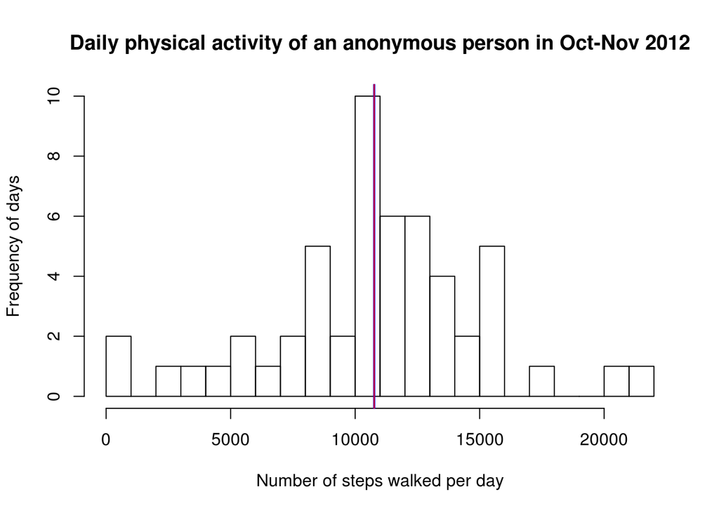

```r
strtit <- "Daily physical activity of an anonymous person in Oct-Nov 2012"
hist(actfagg$sumsteps,  breaks=20, xlab="Number of steps walked per day", ylab="Frequency of days", main=strtit)

abline(v= mean_steps_per_day, lwd =2, col="blue")
abline(v= median_steps_per_day, lwd =1, col="red")
```

In the plot above, the mean value of n = 1.0766 × 10<sup>4</sup> is shown as a blue line, the median as a red line.

### The mean of steps per interval-of-the-day can be calculated as follows.

We assume that there are the same number of 5-Minute-Intervals per measurement day. There are

```r
nintv <- length(unique(actf$interval)); nintv
```

```
## [1] 288
```

intervals per day. After summing up all the steps taken during each interval, we have to normalize each sum by this value.

```r
actfagg3 <- ddply(actf, .(interval), summarize,  meansteps = round(sum(steps)/ nintv, 0))
```

[output not shown]

### This is the interval of the day during which, on average, user made the highest number of steps:

```r
intvmax <- actfagg3[which.max(actfagg3$meansteps),]; intvmax
```

```
##     interval meansteps
## 104      835        38
```

## Are there differences in activity patterns between weekdays and weekends?

This can be visualized with a time series plot.

### Plotting daily averages of steps made, using filtered data:

[figure not shown]

```r
nintv <- length(unique(actf$interval));


days.weekend <- actf[(wday(actf$date) %in% c(6,1)),];
nweekenddays <- nrow(days.weekend)/nintv;
on.weekend <-  ddply(days.weekend, .(interval), summarize,  mean_weekend_steps = round(sum(steps)/nweekenddays, 0)) ;

days.workweek <- actf[! (wday(actf$date) %in% c(6,1)),]
nworkdays <- nrow(days.workweek)/nintv
on.workday <- ddply(days.workweek, .(interval), summarize,  mean_workday_steps = round((sum(steps)/nworkdays), 0))


makePlot(on.weekend, on.workday)
```

## Coping with missing data

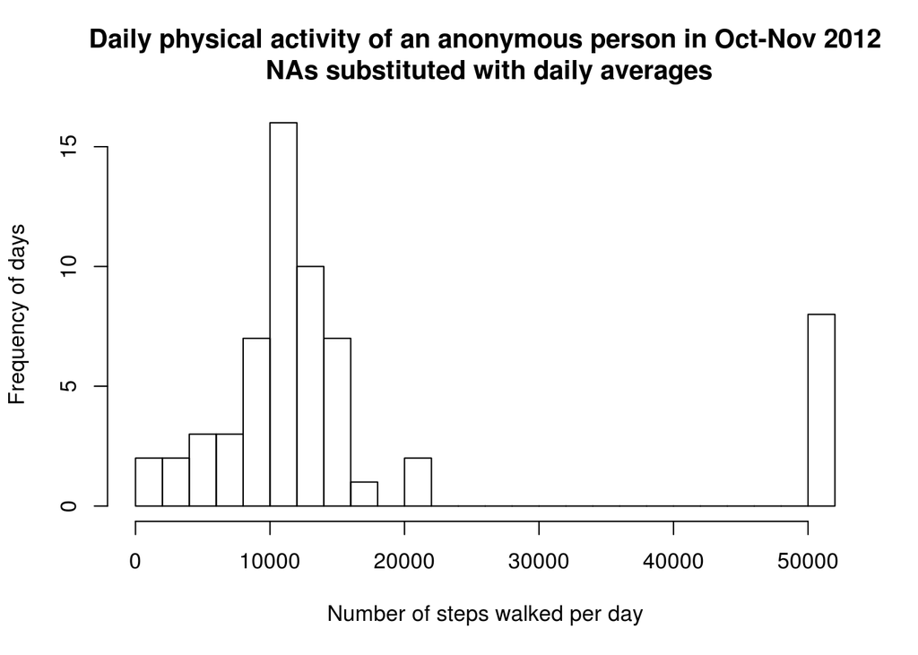

```r
bad <- is.na(act$steps)
act[bad, "steps"] <- mean_steps_per_day/length(unique(act$date))

actagg <- ddply(act, .(date), summarize,  sumsteps = round(sum(steps), 0))



strtit <- paste0("Daily physical activity of an anonymous person in Oct-Nov 2012", "\n", " NAs substituted with daily averages")
hist(actagg$sumsteps,  breaks=20, xlab="Number of steps walked per day", ylab="Frequency of days", main=strtit)
```

[figure not shown]

```r
nintv <- length(unique(act$interval));


days.weekend <- act[(wday(act$date) %in% c(6,1)),];
nweekenddays <- nrow(days.weekend)/nintv;
on.weekend <-  ddply(days.weekend, .(interval), summarize,  mean_weekend_steps = round(sum(steps)/nweekenddays, 0)) ;

days.workweek <- act[! (wday(act$date) %in% c(6,1)),]
nworkdays <- nrow(days.workweek)/nintv
on.workday <- ddply(days.workweek, .(interval), summarize,  mean_workday_steps = round((sum(steps)/nworkdays), 0))

makePlot(on.weekend, on.workday,"missing data replaced with daily median value")
```